# 파노라마 합성 및 객체 검출

> **실험 목표**: SIFT, ORB, ALIKED의 객체 검출 정확도와 실행 시간을 비교하고, 기준 물체의 회전·크기·조명 변화에 대한 강건성을 평가합니다.

> **검출기 변경**: 과제 안내의 AKAZE는 현재 사용 중인 OpenCV 5.0 환경에서 사용할 수 없어 ALIKED로 대체했습니다. ALIKED는 딥러닝 기반 특징점과 LightGlue 매칭을 사용하며, 본 보고서에서는 SIFT·ORB와 함께 성능을 비교합니다.

## 1. 실험 개요

연속 사진을 합성한 파노라마에서 기준 물체의 위치를 찾습니다. 각 방법은 특징점 추출·매칭, Lowe Ratio Test 또는 LightGlue 매칭, RANSAC 기반 호모그래피를 거쳐 검출 결과를 만듭니다.

### 매칭 및 기하 검증 방법

- **Lowe Ratio Test**: SIFT·ORB의 최근접·차근접 매칭 거리를 비교해 모호한 매칭을 제거합니다.
- **LightGlue 매칭**: ALIKED 특징점 사이의 대응 관계를 신경망 기반으로 판단해 신뢰도 높은 매칭을 선택합니다.
- **RANSAC 기반 호모그래피**: 잘못된 매칭(Outlier)을 제외하고, 남은 Inlier로 기준 물체의 평면 좌표 변환과 Polygon 위치를 계산합니다.

## 3. 평가 기준

- **검출 성공률**: 전체 케이스 중 객체 위치 검출에 성공한 비율
- **평균 탐색 시간**: 특징점 추출과 Coarse-to-Fine 타일 탐색에 걸린 시간
- **매칭 신뢰도**: RANSAC Inlier 수와 Inlier 비율
- **변형 조건**: 기준 상태, 회전 ±30°, 크기 75%·125%, 밝기 70%·130%

### 모듈별 역할

- `src/stitcher.py`: 연속 사진의 특징점 매칭, RANSAC, 호모그래피와 블렌딩으로 파노라마를 합성합니다.
- `src/object_finder.py`: 기준 물체 특징점을 재사용해 Coarse-to-Fine 타일 탐색을 수행하고, 최종 호모그래피를 파노라마 좌표의 Polygon으로 표시합니다.
- `src/pipeline.py`: 합성·검출 모듈을 순서대로 실행하고 이미지·요약 JSON을 저장하는 전체 파이프라인 진입점입니다.
- `src/main.py`: 파노라마 합성 또는 객체 검출 기능을 개별로 확인하는 테스트·디버그 도구입니다.
- `src/project_paths.py`: 데이터와 결과물의 공통 경로, 객체 검출 결과 폴더 규칙을 관리합니다.

```python
# ==========================================
# 라이브러리 및 프로젝트 모듈 Import
# - 노트북에서 사용하는 공통 설정과 실행 함수를 한곳에서 준비
# ==========================================
import importlib
import logging
import cv2
import matplotlib.pyplot as plt
import pandas as pd
from IPython.display import display


import src.image_io as image_io
importlib.reload(image_io)

import src.experiment_runner as experiment_runner
import src.object_finder as object_finder
import src.result_cleanup as result_cleanup
import src.settings as settings
import src.stitcher as stitcher
import src.stitcher_create as stitcher_create

importlib.reload(settings)
importlib.reload(image_io)
importlib.reload(stitcher)
importlib.reload(stitcher_create)
importlib.reload(object_finder)
importlib.reload(experiment_runner)
importlib.reload(result_cleanup)

from src.experiment_runner import (
    build_detection_matching_table,
    build_detection_summary_table,
    build_panorama_matching_table,
    collect_panorama_summary,
    create_detection_qualitative_figure,
    create_detection_summary_chart_figure,
    create_builtin_stitcher_result_figure,
    create_panorama_filtered_match_figure,
    create_panorama_matching_gallery_figure,
    create_panorama_result_comparison_figure,
    discover_test_cases,
    get_experiment_settings,
    run_batch,
    run_panorama_experiments,
    save_experiment_csv,
    style_report_table,
    summarize_records,
)
from src.logger import logger
from src.project_paths import (
    OBJECT_DIR,
    PANORAMA_RESULT_DIR,
    PANORAMA_SOURCE_DIR,
)
from src.result_cleanup import clear_results
from src.stitcher_create import run_experiments as run_builtin_stitcher_experiments

plt.rcParams['font.family'] = 'Malgun Gothic'
plt.rcParams['axes.unicode_minus'] = False

# ==========================================
# 노트북 로그 설정
# - 화면과 results/logs/opencv.log에는 ERROR 이상만 기록
# ==========================================
NOTEBOOK_LOG_LEVEL = logging.ERROR
logger.setLevel(NOTEBOOK_LOG_LEVEL)
logger.propagate = False
for handler in logger.handlers:
    handler.setLevel(NOTEBOOK_LOG_LEVEL)

cv2.utils.logging.setLogLevel(cv2.utils.logging.LOG_LEVEL_ERROR)

EXPERIMENT = get_experiment_settings()
```

```python
# ==========================================
# 이전 결과 정리
# - opencv.log와 .gitkeep은 보존
# - False면 삭제 대상만 미리 확인
# ==========================================
DELETE_PREVIOUS_RESULTS = True

cleanup_targets = clear_results(dry_run=not DELETE_PREVIOUS_RESULTS)
print('정리 대상 수:', len(cleanup_targets))
if DELETE_PREVIOUS_RESULTS:
    print('이전 결과 삭제 완료')
else:
    print('미리보기 모드입니다. 삭제하려면 True로 변경하세요.')
```

```
정리 대상 수: 308
이전 결과 삭제 완료
```

## 4. 파노라마 합성 실험

각 `data/setNN` 연속 사진 세트에 SIFT, ORB, ALIKED를 적용해 직접 파노라마를 합성한다. 동일한 세트에 OpenCV 내장 Stitcher도 적용해 기준 결과를 생성하고, 방법별 매칭 품질과 합성 결과를 비교한다.

```python
# ==========================================
# 파노라마 합성 일괄 실행
# - 세트 탐색과 방법별 합성은 experiment_runner.py에서 처리
# ==========================================
panorama_results = run_panorama_experiments(
    source_root=PANORAMA_SOURCE_DIR,
    methods=EXPERIMENT.methods,
    max_side=EXPERIMENT.panorama_max_side,
)

print(f'파노라마 합성 실행 완료: {len(panorama_results)}회')
```

```
파노라마 합성 실행 완료: 15회
```

### 4.1 방법별 파노라마 합성 매칭 통계

인접 사진 쌍의 원시 매칭 수, 필터링 후 매칭 수, RANSAC Inlier 수와 Inlier 비율을 비교한다.

```python
# ==========================================
# 파노라마 합성 매칭 통계 표
# - 세트·방법별 matching_stats.csv를 pandas 표로 표시
# ==========================================
panorama_summary_rows = collect_panorama_summary(
    panorama_result_dir=PANORAMA_RESULT_DIR,
    methods=EXPERIMENT.methods,
)
PANORAMA_MATCHING_TABLE = build_panorama_matching_table(
    panorama_summary_rows
)

display(
    style_report_table(PANORAMA_MATCHING_TABLE, {
        '평균 원시 매칭': '{:,.1f}',
        '평균 필터링 매칭': '{:,.1f}',
        '평균 Inlier': '{:,.1f}',
        '평균 Inlier 비율': '{:.1%}',
    })
)
```

|  | 세트 | 방법 | 사진 쌍 | 평균 원시 매칭 | 평균 필터링 매칭 | 평균 Inlier | 평균 Inlier 비율 |
| --- | --- | --- | --- | --- | --- | --- | --- |
| 0 | set01 | ALIKED | 4 | 438.5 | 438.5 | 369.8 | 85.0% |
| 1 | set01 | ORB | 4 | 21,656.8 | 4,565.8 | 4,021.5 | 87.8% |
| 2 | set01 | SIFT | 4 | 5,086.0 | 1,403.0 | 1,197.5 | 84.9% |
| 3 | set02 | ALIKED | 3 | 519.3 | 519.3 | 394.3 | 76.0% |
| 4 | set02 | ORB | 3 | 11,318.3 | 1,861.3 | 1,511.3 | 80.7% |
| 5 | set02 | SIFT | 3 | 2,215.0 | 490.0 | 386.7 | 78.7% |
| 6 | set03 | ALIKED | 4 | 360.8 | 360.8 | 321.5 | 88.3% |
| 7 | set03 | ORB | 4 | 30,669.5 | 4,495.0 | 3,707.2 | 81.3% |
| 8 | set03 | SIFT | 4 | 4,312.0 | 930.5 | 741.0 | 79.7% |
| 9 | set04 | ALIKED | 2 | 384.0 | 384.0 | 350.0 | 91.2% |
| 10 | set04 | ORB | 2 | 29,257.5 | 4,203.0 | 4,006.5 | 95.2% |
| 11 | set04 | SIFT | 2 | 5,311.0 | 1,096.0 | 981.5 | 89.4% |
| 12 | set05 | ALIKED | 2 | 348.0 | 348.0 | 250.0 | 72.3% |
| 13 | set05 | ORB | 2 | 35,741.0 | 4,775.5 | 4,391.5 | 92.1% |
| 14 | set05 | SIFT | 2 | 9,600.0 | 1,369.5 | 929.5 | 68.2% |

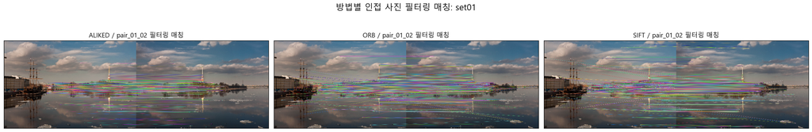

```python
# ==========================================
# 방법별 인접 사진 필터링 매칭 결과
# - 첫 번째 사진 쌍(01.jpg <-> 02.jpg)의 필터링 결과를 비교
# ==========================================
create_panorama_filtered_match_figure(
    summary_rows=panorama_summary_rows,
    panorama_result_dir=PANORAMA_RESULT_DIR,
    pyplot=plt,
)
plt.show()
```

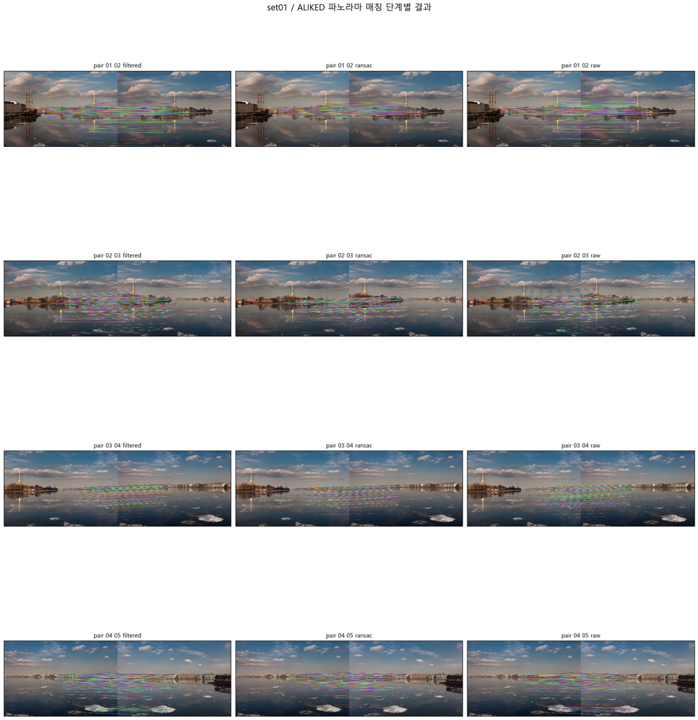

```python
# ==========================================
# 파노라마 매칭 이미지 전체 확인
# - raw / filtered / ransac 단계별 이미지를 모두 표시
# ==========================================
MATCHING_VISUAL_SET = 'set01'
MATCHING_VISUAL_METHOD = 'ALIKED'

create_panorama_matching_gallery_figure(
    panorama_result_dir=PANORAMA_RESULT_DIR,
    set_name=MATCHING_VISUAL_SET,
    method=MATCHING_VISUAL_METHOD,
    pyplot=plt,
)
plt.show()
```

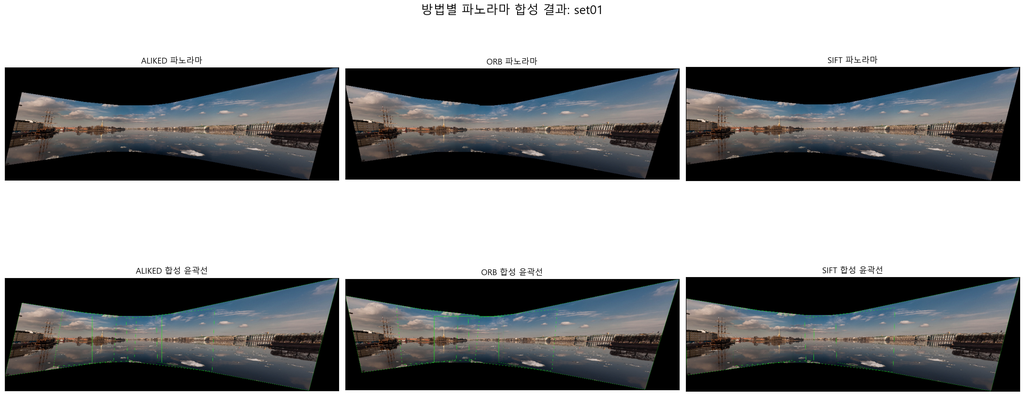

```python
# ==========================================
# 방법별 파노라마 합성 결과 시각 비교
# - 파노라마와 합성 윤곽선 이미지를 방법별로 표시
# ==========================================
create_panorama_result_comparison_figure(
    summary_rows=panorama_summary_rows,
    pyplot=plt,
)
plt.show()
```

### 4.2 OpenCV 내장 Stitcher 비교

`cv2.Stitcher_create()`로 동일한 연속 사진 세트를 합성한다. 결과는 `results/panorama/create/세트명/panorama.jpg`에 저장하며, 직접 구현한 방법별 결과와 비교 기준으로 사용한다.

```python
# ==========================================
# OpenCV 내장 Stitcher 파노라마 생성
# - data/setNN 세트를 자동 탐색
# - 결과는 results/panorama/create/세트명/에 저장
# ==========================================
builtin_stitcher_results = run_builtin_stitcher_experiments(
    max_side=EXPERIMENT.panorama_max_side,
)

print(f'OpenCV 내장 Stitcher 실행 완료: {len(builtin_stitcher_results)}회')
```

```
OpenCV 내장 Stitcher 실행 완료: 5회
```

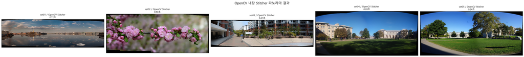

```python
# ==========================================
# OpenCV 내장 Stitcher 결과 이미지 출력
# ==========================================
create_builtin_stitcher_result_figure(
    result_rows=builtin_stitcher_results,
    pyplot=plt,
)
plt.show()
```

## 5. 객체 검출 탐색 설정

검출용 파노라마는 긴 변 3072로 축소한 뒤 탐색하며, 최종 Polygon은 원본 파노라마 좌표로 복원한다. 타일 크기, 탐색 간격, 후보 수, 조기 종료 기준은 `config.json`의 객체 검출 설정을 사용한다. 기준 물체에는 기본 조건과 회전·크기·조명 변화 6개 조건을 적용한다.

```python
# ==========================================
# 객체 검출 공통 환경 확인
# ==========================================
print('방법:', ', '.join(EXPERIMENT.methods))
print(
    '타일:', EXPERIMENT.tile_size,
    '| Coarse:', EXPERIMENT.coarse_stride,
    '| Fine:', EXPERIMENT.fine_stride,
)
print('검출용 파노라마 최대 변:', EXPERIMENT.detection_max_side)
print('실험 조건 수:', len(EXPERIMENT.conditions))
```

```
방법: SIFT, ORB, ALIKED
타일: (512, 512) | Coarse: (512, 512) | Fine: (256, 256)
검출용 파노라마 최대 변: 3072
실험 조건 수: 7
```

## 6. 객체 검출 테스트 세트 자동 탐색

`data/objects/setN/target.jpg`와 `results/panorama/setN/방법/panorama.jpg`를 세트 번호로 연결한다. 파노라마 세트와 기준 물체가 추가되면 같은 방식으로 자동 확장된다.

```python
# ==========================================
# 테스트 데이터 자동 탐색
# - setN/target.jpg와 setN/panorama.jpg를 세트 번호로 연결
# ==========================================
TEST_CASES = discover_test_cases(
    target_dir=OBJECT_DIR,
    panorama_result_dir=PANORAMA_RESULT_DIR,
    methods=EXPERIMENT.methods,
)

print('자동 탐색된 테스트 세트 수:', len(TEST_CASES))
print(
    '총 실험 횟수:',
    len(TEST_CASES) * len(EXPERIMENT.methods) * len(EXPERIMENT.conditions),
)
```

```
자동 탐색된 테스트 세트 수: 5
총 실험 횟수: 105
```

## 7. 객체 검출 일괄 실행

각 테스트 세트와 변형 조건에서 SIFT, ORB, ALIKED를 실행한다. 기본 조건의 검출 결과와 최종 Fine Tile 매칭 이미지는 저장하고, 전체 결과는 CSV로 저장한다.

```python
# ==========================================
# 객체 검출 일괄 실행 및 CSV 저장
# ==========================================
batch_records = run_batch(
    test_cases=TEST_CASES,
    methods=EXPERIMENT.methods,
    conditions=EXPERIMENT.conditions,
    tile_size=EXPERIMENT.tile_size,
    coarse_stride=EXPERIMENT.coarse_stride,
    fine_stride=EXPERIMENT.fine_stride,
    coarse_top_k=EXPERIMENT.coarse_top_k,
    early_stop_inliers=EXPERIMENT.early_stop_inliers,
    result_root=EXPERIMENT.result_root,
    matching_root=EXPERIMENT.matching_root,
    detection_max_side=EXPERIMENT.detection_max_side,
)

summary_rows = summarize_records(batch_records)
csv_paths = save_experiment_csv(
    records=batch_records,
    summary=summary_rows,
    output_dir=EXPERIMENT.metrics_dir,
)

print('실행 완료:', len(batch_records), '회')
print('원시 결과 CSV:', csv_paths['records'])
print('요약 통계 CSV:', csv_paths['summary'])
```

```
실행 완료: 105 회
원시 결과 CSV: D:\workspace\OpenCV\results\object_detection\metrics\experiment_records.csv
요약 통계 CSV: D:\workspace\OpenCV\results\object_detection\metrics\method_condition_summary.csv
```

## 8. 객체 검출 정량적 결과 비교

방법·변형 조건별 성공률, 평균 탐색 시간, 평균 Inlier 비율을 비교한다.

```python
DETECTION_SUMMARY_TABLE = build_detection_summary_table(
    summary_rows=summary_rows,
    experiment=EXPERIMENT,
)
display(
    style_report_table(DETECTION_SUMMARY_TABLE, {
        '검출 성공률': '{:.1%}',
        '평균 시간(초)': '{:,.3f}',
        '평균 Inlier': '{:,.1f}',
        '평균 Inlier 비율': '{:.1%}',
    })
)
```

|  | 조건 | 방법 | 검출 성공 | 검출 성공률 | 평균 시간(초) | 평균 Inlier | 평균 Inlier 비율 |
| --- | --- | --- | --- | --- | --- | --- | --- |
| 0 | 기본 | SIFT | 5/5 | 100.0% | 0.495 | 82.2 | 91.5% |
| 1 | 기본 | ORB | 4/5 | 80.0% | 0.366 | 232.2 | 81.2% |
| 2 | 기본 | ALIKED | 5/5 | 100.0% | 37.842 | 152.2 | 82.2% |
| 3 | 회전 -30° | SIFT | 5/5 | 100.0% | 0.367 | 89.2 | 84.7% |
| 4 | 회전 -30° | ORB | 5/5 | 100.0% | 0.289 | 226.2 | 79.6% |
| 5 | 회전 -30° | ALIKED | 5/5 | 100.0% | 36.934 | 156.0 | 86.2% |
| 6 | 회전 +30° | SIFT | 4/5 | 80.0% | 0.348 | 101.5 | 89.3% |
| 7 | 회전 +30° | ORB | 5/5 | 100.0% | 0.274 | 228.0 | 76.9% |
| 8 | 회전 +30° | ALIKED | 5/5 | 100.0% | 39.170 | 158.4 | 89.8% |
| 9 | 크기 75% | SIFT | 5/5 | 100.0% | 0.325 | 85.2 | 92.2% |
| 10 | 크기 75% | ORB | 4/5 | 80.0% | 0.148 | 80.2 | 84.3% |
| 11 | 크기 75% | ALIKED | 5/5 | 100.0% | 38.870 | 149.6 | 89.4% |
| 12 | 크기 125% | SIFT | 5/5 | 100.0% | 0.366 | 101.6 | 82.1% |
| 13 | 크기 125% | ORB | 3/5 | 60.0% | 0.240 | 264.0 | 98.3% |
| 14 | 크기 125% | ALIKED | 5/5 | 100.0% | 37.475 | 147.4 | 80.2% |
| 15 | 조명 70% | SIFT | 5/5 | 100.0% | 0.297 | 68.4 | 92.5% |
| 16 | 조명 70% | ORB | 4/5 | 80.0% | 0.177 | 197.5 | 89.4% |
| 17 | 조명 70% | ALIKED | 5/5 | 100.0% | 38.615 | 151.2 | 84.2% |
| 18 | 조명 130% | SIFT | 5/5 | 100.0% | 0.302 | 82.0 | 88.9% |
| 19 | 조명 130% | ORB | 4/5 | 80.0% | 0.231 | 227.5 | 79.2% |
| 20 | 조명 130% | ALIKED | 5/5 | 100.0% | 39.384 | 152.8 | 82.9% |

### 8.1 방법별 객체 검출 매칭 통계

기본 조건에서 최종 선택된 Fine Tile을 기준으로 방법별 매칭 품질을 비교한다. `평균 RANSAC 전 매칭`은 SIFT·ORB의 Ratio Test 후, ALIKED의 LightGlue 매칭 후의 수이며, `평균 Inlier`와 `평균 Inlier 비율`은 검출 성공 케이스만 평균낸 값이다.

```python
# ==========================================
# 방법별 객체 검출 최종 Tile 매칭 통계 표
# - 기본 조건의 검출 성공 케이스를 기준으로 pandas 집계
# ==========================================
MATCHING_VISUAL_CONDITION = 'baseline'
DETECTION_MATCHING_TABLE = build_detection_matching_table(
    records=batch_records,
    experiment=EXPERIMENT,
    visual_condition=MATCHING_VISUAL_CONDITION,
)

display(
    style_report_table(DETECTION_MATCHING_TABLE, {
        '평균 기준 특징점': '{:,.1f}',
        '평균 RANSAC 전 매칭': '{:,.1f}',
        '평균 Inlier': '{:,.1f}',
        '평균 Inlier 비율': '{:.1%}',
    })
)
```

|  | 방법 | 검출 성공 | 평균 기준 특징점 | 평균 RANSAC 전 매칭 | 평균 Inlier | 평균 Inlier 비율 |
| --- | --- | --- | --- | --- | --- | --- |
| 0 | SIFT | 5/5 | 1,401.8 | 93.6 | 82.2 | 91.5% |
| 1 | ORB | 4/5 | 4,204.0 | 266.0 | 232.2 | 81.2% |
| 2 | ALIKED | 5/5 | 1,000.0 | 163.6 | 152.2 | 82.2% |

### 8.2 조건별 성공률과 처리 시간

회전·크기·조명 변화가 검출 성공률과 평균 실행 시간에 미치는 영향을 방법별 막대그래프로 비교한다.

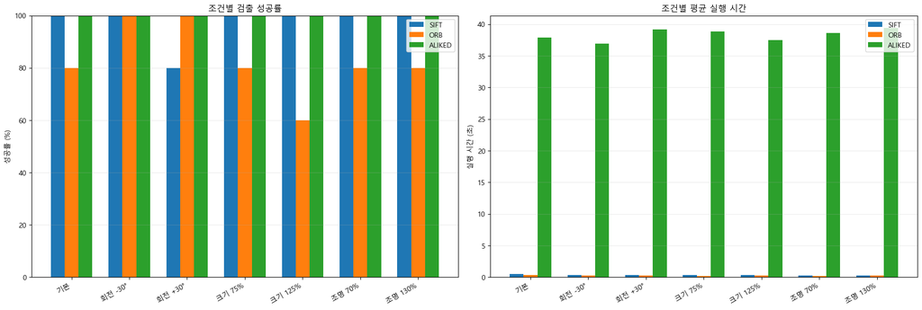

```python
create_detection_summary_chart_figure(
    summary_rows=summary_rows,
    experiment=EXPERIMENT,
    pyplot=plt,
)
plt.show()
```

## 9. 객체 검출 정성적 결과 확인

위 행은 파노라마에서 검출된 물체의 Global Polygon이고, 아래 행은 같은 방법에서 선택된 최종 Fine Tile의 Keypoint Matches이다. 수치 결과와 함께 Polygon 위치와 매칭 분포를 확인한다.

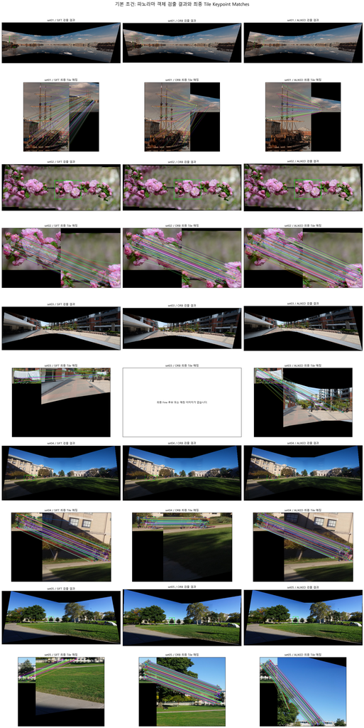

```python
# ==========================================
# 기본 조건 검출 결과 및 최종 Tile 매칭 시각화
# ==========================================
VISUAL_CONDITION = 'baseline'

create_detection_qualitative_figure(
    test_cases=TEST_CASES,
    experiment=EXPERIMENT,
    pyplot=plt,
    visual_condition=VISUAL_CONDITION,
)
plt.show()
```

## 10. 실패 사례 분석

### 10.1 파노라마 합성

cafeteria와 roof의 연속 사진 `01.jpg`~`05.jpg`를 대상으로, `--max-side 4000` 조건에서 SIFT·ORB·ALIKED의 파노라마 생성 실패를 분석하였다. 두 프로젝트의 입력 사진은 동일하며, 원본이 4000×2252이므로 이 조건에서는 입력 축소가 없었다.

- **직접 구현의 실패 원인:** 여섯 조건 모두 인접 사진의 매칭과 RANSAC 호모그래피 추정 및 최소 Inlier 검사를 통과했다. 그러나 중앙 `03.jpg` 기준으로 변환을 누적한 뒤, 끝쪽 사진 내부에서 투영 분모가 0을 지나 좌표가 무한대로 향하는 문제가 발생했다. 이에 따라 `불안정한 호모그래피입니다` 검사에서 중단되었으며, 캔버스 크기 검사와 블렌딩에는 도달하지 않았다. 따라서 특징점 부족이나 블렌딩 문제로 설명할 수 없다.
- **내장 Stitcher 결과 확인:** 기존 성공 파노라마는 아래의 각 3장을 선택한 상태로 재현했을 때 저장 JPEG와 바이트 단위로 완전히 일치했다. 즉, 결과 파일 생성 성공을 입력 5장 전체의 합성 성공과 구분해야 한다.

| 데이터셋 | 내장 Stitcher가 선택한 사진 | 제외된 사진 |
| --- | --- | --- |
| cafeteria | 02·03·04 | 01·05 |
| roof | 03·04·05 | 01·02 |

**해석 및 개선 방향:** 직접 구현은 인접 호모그래피를 누적해 하나의 평면에 투영하지만, 내장 Stitcher는 입력 선별·전역 카메라 조정·구면 투영을 사용한다. 따라서 이번 결과는 특징점 알고리즘의 우열보다 전체 합성 방식과 사용된 입력 범위의 차이를 보여준다. 넓은 시야의 평면 투영 한계와 부합하나, 추정·누적 오차의 영향도 분리하지 못했다. 후속 비교에서는 사용 사진 수와 시야 범위를 함께 기록하고, 동일한 입력 부분집합 및 구면·원통 투영을 검토해야 한다. 캔버스 제한 증가나 블렌딩 교체만으로 이번 중단 원인을 해결할 수는 없다.

위 실패 위치는 현재 코드의 재현 결과이며, 24쌍의 매칭 수치 72개가 기존 로그와 모두 일치했다. 과거 변환 행렬 자체는 로그에 저장되어 있지 않아 직접 대조하지 못했다.

### 10.2 객체 검출

10.2.1 AKAZE 사용 제한

- **원인:** OpenCV 5.0 환경에서 AKAZE를 사용할 수 없어 대체 특징점 검출기가 필요했다.
- **개선 방향:** 회전과 조명 변화에 강한 **ALIKED**를 대체 방법으로 적용하고 SIFT·ORB와 비교하였다. ALIKED의 높은 강건성을 확인했으나 CPU 처리 시간이 길다는 한계도 확인하였다.

10.2.2 파노라마 전체 1:1 매칭의 한계

- **원인:** 기준 물체와 큰 파노라마를 한 번에 매칭하면 특징점 수와 해상도 차이로 인해 처리 시간이 길어지고 오매칭 가능성이 높아졌다.
- **개선 방향:** 파노라마를 **Coarse Tile로 먼저 탐색한 뒤 상위 후보만 Fine Tile로 재탐색하는 Coarse-to-Fine 방식**을 적용하였다.

10.2.3 고해상도 파노라마 탐색 시간 증가

- **원인:** 고해상도 파노라마를 원본 크기로 탐색하면 ALIKED의 실행 시간이 크게 증가했다.
- **개선 방향:** 탐색용 이미지의 긴 변을 **3072픽셀 이하로 축소**하고, 호모그래피로 계산한 Polygon과 Tile 좌표는 축소 비율의 역수를 적용하여 원본 좌표로 복원하였고 파노라마의 검은 영역이 70%이상일 경우 처리하지 않도록 적용하였다.

10.2.5 CPU 환경에 따른 처리 시간 문제

- **원인:** 동일한 CPU 전체 실험이 개인 PC에서는 약 22분, 실습실 PC에서는 약 200분이 소요되어 실행 환경에 따른 처리 시간 차이가 크게 나타났다.
- **개선 방향:** 별도 GPU 환경에 **PyTorch ALIKED-n16rot·LightGlue 기반 검출기**를 구현하였다. 원본 해상도 기준 5개 세트의 기본 조건 검출에 모두 성공했으며, CPU의 105회 변형 조건 실험과는 모델·실행 조건이 다르므로 GPU 결과는 별도의 성능 검증 결과로 관리하였다.

## 11. 결론 및 한계

### 11.1 객체 검출 결과

5개 파노라마 세트에서 기준 조건과 회전·크기·조명 변화 6종을 적용하여 총 105회 실험하였다. 이 중 98회가 검출에 성공하여 전체 성공률은 **93.3%**였다.

[output not shown]

SIFT는 `rotation_plus30` 조건의 set03에서만 실패했다. ORB는 기준·조명 변화·축소 조건에서 각 1회, 1.25배 확대 조건에서 2회 실패하여 크기 변화에 가장 민감했다. 반면 ALIKED는 모든 조건에서 성공률 100%를 유지했다. 따라서 정확도가 우선인 오프라인 검사에는 ALIKED가 적합하고, 빠른 처리와 높은 성공률을 함께 요구하는 환경에는 SIFT가 적합하다. ORB는 실시간성이 최우선이고 일부 실패를 허용할 수 있을 때 선택할 수 있다.

최종 결과 이미지와 Keypoint Matches 이미지에서 기준 물체의 특징점이 동일한 Fine Tile에 집중되고, RANSAC Inlier를 사용해 계산한 Global Polygon이 해당 위치를 가리키는 것을 확인했다. 파노라마 긴 변을 3072픽셀로 축소해 탐색한 뒤 Polygon 좌표를 원본 크기로 복원하여, 대형 파노라마의 탐색 시간도 줄였다.

### 11.2 파노라마 합성 결과

5개 세트의 인접 이미지 쌍 15개를 비교한 결과, 평균 RANSAC Inlier 비율은 ORB 86.2%, ALIKED 83.2%, SIFT 80.6%였다. ORB는 평균 원시 매칭 수가 24,883.8개로 가장 많았지만 Lowe Ratio Test 후 평균 3,985.6개로 줄었다. SIFT도 평균 4,937.3개에서 1,049.0개로 감소했다. ALIKED는 평균 414.6개의 매칭을 유지했으며, 매칭 수 자체보다 RANSAC 후 남은 기하학적으로 일관된 대응점이 합성 품질에 중요함을 확인했다.

직접 구현한 합성은 호모그래피와 페더 블렌딩으로 연속 사진을 연결하는 과정을 확인하는 데 적합했다. 다만 넓은 시야각에서는 `warpPerspective` 뒤 유효 영역이 사각형을 완전히 채우지 않아 위·아래에 검은 여백이 남았다. `cv2.Stitcher_create()` 결과는 카메라 추정과 원통·구면 계열 워핑, 자동 크롭을 적용하므로 비교 결과에서 여백이 더 적고 자연스럽게 보였다.